# GEOG 4/6300 Midterm Data Sprint: Numbat Sightings

Are numbat sightings more frequent in summer or winter in Australia?

Author

Emmanuel Mensah

Published

# Introduction

For this project, I am using the **Numbats in Australia** dataset from [TidyTuesday (March 7, 2023)](https://github.com/rfordatascience/tidytuesday/tree/main/data/2023/2023-03-07). The observations originally came from the Atlas of Living Australia. Each row is a recorded numbat occurrence or sighting, rather than a count of every numbat in the wild.

The data include the **date** of a record (`eventDate`), the **month** (`month`), the **year** (`year`), the **location** (`decimalLatitude` and `decimalLongitude`), and the **source** of the record (`dataResourceName`). The dataset also includes information about time of day and weather, although I will focus on the month to answer my question.

**Research question: Are numbat sightings more frequent in summer or winter in Australia?**

I chose this question because I can use the `month` variable to group records into seasons and compare the number of sightings. Since Australia is in the Southern Hemisphere, **summer is December–February** and **winter is June–August**.

# Analysis

## 1. Load and explore the dataset

First, I load the `tidyverse` package and read the CSV file. I use `glimpse()` to look at the columns and `nrow()` to check how many observations I have.

```r
library(tidyverse)

numbats <- read_csv("numbats.csv", show_col_types = FALSE)

glimpse(numbats)
```

```
Rows: 805
Columns: 17
$ decimalLatitude  <dbl> -37.65000, -35.10341, -35.00000, -34.70000, -34.60000…
$ decimalLongitude <dbl> 145.5333, 150.2570, 117.5000, 117.8000, 117.3000, 117…
$ eventDate        <dttm> NA, 2014-06-05 02:00:00, NA, NA, NA, NA, NA, NA, NA,…
$ scientificName   <chr> "Myrmecobius fasciatus", "Myrmecobius fasciatus", "My…
$ taxonConceptID   <chr> "https://biodiversity.org.au/afd/taxa/6c72d199-f0f1-4…
$ recordID         <chr> "73830609-3d94-461f-a833-01c0a30c5a0d", "13287c0e-034…
$ dataResourceName <chr> "Queen Victoria Museum Art Gallery provider for OZCAM…
$ occurrenceStatus <chr> "PRESENT", "PRESENT", "PRESENT", "PRESENT", "PRESENT"…
$ year             <dbl> NA, 2014, NA, NA, NA, NA, NA, NA, NA, NA, 2016, 2019,…
$ month            <chr> NA, "Jun", NA, NA, NA, NA, NA, NA, NA, NA, "Nov", "No…
$ wday             <chr> NA, "Thu", NA, NA, NA, NA, NA, NA, NA, NA, "Tue", "We…
$ hour             <dbl> NA, 2, NA, NA, NA, NA, NA, NA, NA, NA, 13, 13, 13, 13…
$ day              <date> NA, 2014-06-05, NA, NA, NA, NA, NA, NA, NA, NA, 2016…
$ dryandra         <chr> "no", "no", "no", "no", "no", "no", "no", "no", "no",…
$ prcp             <dbl> NA, NA, NA, NA, NA, NA, NA, NA, NA, NA, NA, NA, NA, N…
$ tmax             <dbl> NA, NA, NA, NA, NA, NA, NA, NA, NA, NA, NA, NA, NA, N…
$ tmin             <dbl> NA, NA, NA, NA, NA, NA, NA, NA, NA, NA, NA, NA, NA, N…
```

```r
nrow(numbats)
```

```
[1] 805
```

The dataset contains **805 records**.

## 2. Check missing values and clean the data

To compare seasons, I need a month for each record. I first count missing months, then use `filter()` to keep records with a month.

```r
sum(is.na(numbats$month))
```

```
[1] 253
```

```r
numbats_clean <- numbats %>%
  filter(!is.na(month))

nrow(numbats_clean)
```

```
[1] 552
```

I found **253 records without a month**, so **552 records** remain for my seasonal comparison. Removing missing months helps me avoid assigning a season to a record when its date is unknown.

## 3. Group the months into seasons

Next, I use `mutate()` and `case_when()` to create a new column called `season`. I make `month` an ordered factor so the months will appear from January to December in my graph.

```r
numbats_clean <- numbats_clean %>%
  mutate(
    season = case_when(
      month %in% c("Dec", "Jan", "Feb") ~ "Summer",
      month %in% c("Mar", "Apr", "May") ~ "Autumn",
      month %in% c("Jun", "Jul", "Aug") ~ "Winter",
      month %in% c("Sep", "Oct", "Nov") ~ "Spring"
    ),
    month = factor(month, levels = month.abb)
  ) %>%
  filter(!is.na(season))

season_counts <- numbats_clean %>%
  count(season, name = "sightings") %>%
  arrange(desc(sightings))

season_counts
```

```
# A tibble: 4 × 2
  season sightings
  <chr>      <int>
1 Spring       283
2 Summer       217
3 Autumn        29
4 Winter        23
```

The table shows **283 sightings in spring**, **217 in summer**, **29 in autumn**, and **23 in winter**. I will focus on summer and winter because that is my research question.

## 4. Visualization 1: Sightings in each month

Here I use `count()` to find how many sightings were recorded in each month. I then use `ggplot()` and `geom_col()` to create a bar graph. This helps me see the monthly pattern before comparing seasons.

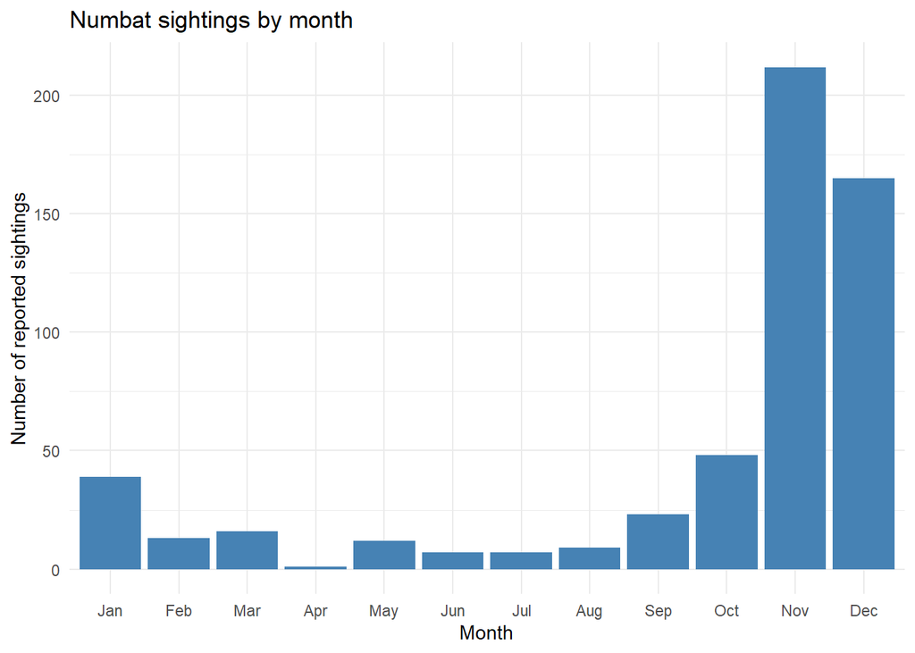

```r
monthly_counts <- numbats_clean %>%
  count(month, name = "sightings")

ggplot(monthly_counts, aes(x = month, y = sightings)) +
  geom_col(fill = "steelblue") +
  labs(
    title = "Numbat sightings by month",
    x = "Month",
    y = "Number of reported sightings"
  ) +
  theme_minimal()
```

```r
ggsave("Numbats_Monthly.png",
       width = 8,
       height = 5)
```

## 5. Visualization 2: Summer versus winter

Now I use `filter()` to select only summer and winter, then `count()` to compare them directly. The numbers are added above the bars so it is easier to read the results.

```r
summer_winter <- numbats_clean %>%
  filter(season %in% c("Summer", "Winter")) %>%
  count(season, name = "sightings") %>%
  mutate(season = factor(season, levels = c("Summer", "Winter")))

summer_winter
```

```
# A tibble: 2 × 2
  season sightings
  <fct>      <int>
1 Summer       217
2 Winter        23
```

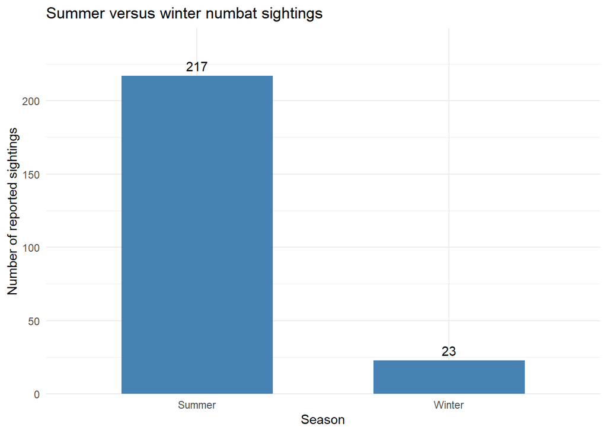

```r
ggplot(summer_winter, aes(x = season, y = sightings)) +
  geom_col(fill = "steelblue", width = 0.6) +
  geom_text(aes(label = sightings), vjust = -0.5) +
  scale_y_continuous(expand = expansion(mult = c(0, 0.15))) +
  labs(
    title = "Summer versus winter numbat sightings",
    x = "Season",
    y = "Number of reported sightings"
  ) +
  theme_minimal()
```

```r
ggsave("Numbats_Summer_Winter.png",
       width = 8,
       height = 5)
```

Figure 2 shows **217 summer sightings compared with only 23 winter sightings**. I can calculate the ratio using the values from my table.

```r
summer_n <- summer_winter %>%
  filter(season == "Summer") %>%
  pull(sightings)

winter_n <- summer_winter %>%
  filter(season == "Winter") %>%
  pull(sightings)

summer_n / winter_n
```

```
[1] 9.434783
```

The result is about **9.4**, meaning there are approximately **9.4 times as many summer sighting records as winter records** in this dataset.

## Discussion

# Tie to Class

This exercise gave me a chance to practice at least three important skills we have covered in GEOG 4/6300:

1. **Loading and exploring data.** I used `read_csv()`, `glimpse()`, and `nrow()` to learn about the dataset and its variables before analyzing it. This is similar to the first steps of our class labs.
2. **Cleaning and transforming data.** I used `filter()` to remove observations that had no month. I also used `mutate()` and `case_when()` to create a new season variable and `count()` to summarize sightings. This showed me how to change raw observations into data that I can compare.
3. **Creating and interpreting visualizations.** I used `ggplot()` with `geom_col()` to create two graphs. The monthly graph helped me explore the pattern, while the summer–winter graph helped me answer the question directly.
4. **Thinking critically about results.** I considered missing data and uneven reporting across seasons. I learned that finding a pattern in data is different from proving why that pattern happens.

# Data source

TidyTuesday (2023, March 7), *Numbats in Australia*: [GitHub dataset and description](https://github.com/rfordatascience/tidytuesday/tree/main/data/2023/2023-03-07). Original sightings: [Atlas of Living Australia](https://www.ala.org.au/).